# Homework 1: Insights on Poverty

February 4, 2016

**This homework is due Sunday February 14, 2016 at 11:59 PM. When complete, submit your code in the R Markdown file and the knitted HTML file on Canvas.**

# Background

This HW is based on Hans Rosling talks [New Insights on Poverty](https://www.ted.com/talks/hans_rosling_reveals_new_insights_on_poverty?language=en) and [The Best Stats You’ve Ever Seen](https://www.ted.com/talks/hans_rosling_shows_the_best_stats_you_ve_ever_seen).

1. Sri Lanka or Turkey
2. Poland or South Korea
3. Malaysia or Russia
4. Pakistan or Vietnam
5. Thailand or South Africa

Most people get them wrong. Why is this? In part it is due to our preconceived notion that the world is divided into two groups: the *Western world* versus the *third world*, characterized by “long life,small family” and “short life, large family” respectively. In this homework we will use data visualization to gain insights on this topic.

# Problem 1

The first step in our analysis is to download and organize the data. The necessary data to answer these question is available on the [gapminder](http://www.gapminder.org/data/) website.

## Problem 1.1

We will use the following datasets:

1. [Childhood mortality](http://spreadsheets.google.com/pub?key=0ArfEDsV3bBwCcGhBd2NOQVZ1eWowNVpSNjl1c3lRSWc&output=csv)
2. [Life expectancy](http://spreadsheets.google.com/pub?key=phAwcNAVuyj2tPLxKvvnNPA&output=csv)
3. [Fertility](http://spreadsheets.google.com/pub?key=phAwcNAVuyj0TAlJeCEzcGQ&output=csv)
4. [Population](http://spreadsheets.google.com/pub?key=phAwcNAVuyj0XOoBL_n5tAQ&output=csv)
5. [Total GDP](http://spreadsheets.google.com/pub?key=pyj6tScZqmEfI4sLVvEQtHw&output=csv)

Create five `tbl_df` table objects, one for each of the tables provided in the above files. Hints: Use the `read_csv` function. Because these are only temporary files, give them short names.

```r
pop <- read.csv("indicator gapminder population - Data.csv")
u5Mort <- read.csv("indicator gapminder under5mortality - Data.csv")
gdp <- read.csv("indicator GDP at market prices, constant 2000 US$ (WB estimates) .xls - Data.csv")
life_exp <- read.csv("indicator life_expectancy_at_birth - Data.csv")
fertile <- read.csv("indicator undata total_fertility - Data.csv")
```

## Problem 1.2

Write a function called `my_func` that takes a table as an argument and returns the column name. For each of the five tables, what is the name of the column containing the country names? Print out the tables or look at them with `View` to determine the column.

```r
my_func <- function(x){
  return(names(x))
}
my_func(pop)
```

```
##  [1] "Total.population" "X1800"            "X1810"
##  [4] "X1820"            "X1830"            "X1840"
##  [7] "X1850"            "X1860"            "X1870"
## [10] "X1880"            "X1890"            "X1900"
## [13] "X1910"            "X1920"            "X1930"
## [16] "X1940"            "X1950"            "X1951"
## [19] "X1952"            "X1953"            "X1954"
## [22] "X1955"            "X1956"            "X1957"
## [25] "X1958"            "X1959"            "X1960"
## [28] "X1961"            "X1962"            "X1963"
## [31] "X1964"            "X1965"            "X1966"
## [34] "X1967"            "X1968"            "X1969"
## [37] "X1970"            "X1971"            "X1972"
## [40] "X1973"            "X1974"            "X1975"
## [43] "X1976"            "X1977"            "X1978"
## [46] "X1979"            "X1980"            "X1981"
## [49] "X1982"            "X1983"            "X1984"
## [52] "X1985"            "X1986"            "X1987"
## [55] "X1988"            "X1989"            "X1990"
## [58] "X1991"            "X1992"            "X1993"
## [61] "X1994"            "X1995"            "X1996"
## [64] "X1997"            "X1998"            "X1999"
## [67] "X2000"            "X2001"            "X2002"
## [70] "X2003"            "X2004"            "X2005"
## [73] "X2006"            "X2007"            "X2008"
## [76] "X2009"            "X2010"            "X2011"
## [79] "X2012"            "X2013"            "X2014"
## [82] "X2015"
```

```r
my_func(u5Mort)
```

```
##   [1] "Under.five.mortality" "X1800"                "X1801"
##   [4] "X1802"                "X1803"                "X1804"
##   [7] "X1805"                "X1806"                "X1807"
##  [10] "X1808"                "X1809"                "X1810"
##  [13] "X1811"                "X1812"                "X1813"
##  [16] "X1814"                "X1815"                "X1816"
##  [19] "X1817"                "X1818"                "X1819"
##  [22] "X1820"                "X1821"                "X1822"
##  [25] "X1823"                "X1824"                "X1825"
##  [28] "X1826"                "X1827"                "X1828"
##  [31] "X1829"                "X1830"                "X1831"
##  [34] "X1832"                "X1833"                "X1834"
##  [37] "X1835"                "X1836"                "X1837"
##  [40] "X1838"                "X1839"                "X1840"
##  [43] "X1841"                "X1842"                "X1843"
```

[output cut: 58 more lines]

```r
my_func(gdp)
```

```
##  [1] "GDP..constant.2000.US.." "X1960"
##  [3] "X1961"                   "X1962"
##  [5] "X1963"                   "X1964"
##  [7] "X1965"                   "X1966"
##  [9] "X1967"                   "X1968"
## [11] "X1969"                   "X1970"
## [13] "X1971"                   "X1972"
## [15] "X1973"                   "X1974"
## [17] "X1975"                   "X1976"
## [19] "X1977"                   "X1978"
## [21] "X1979"                   "X1980"
## [23] "X1981"                   "X1982"
## [25] "X1983"                   "X1984"
## [27] "X1985"                   "X1986"
## [29] "X1987"                   "X1988"
## [31] "X1989"                   "X1990"
## [33] "X1991"                   "X1992"
## [35] "X1993"                   "X1994"
## [37] "X1995"                   "X1996"
## [39] "X1997"                   "X1998"
## [41] "X1999"                   "X2000"
## [43] "X2001"                   "X2002"
## [45] "X2003"                   "X2004"
## [47] "X2005"                   "X2006"
## [49] "X2007"                   "X2008"
## [51] "X2009"                   "X2010"
## [53] "X2011"
```

```r
my_func(life_exp)
```

```
##   [1] "Life.expectancy.with.projections..Yellow.is.IHME"
##   [2] "X1800"
##   [3] "X1801"
##   [4] "X1802"
##   [5] "X1803"
##   [6] "X1804"
##   [7] "X1805"
##   [8] "X1806"
##   [9] "X1807"
##  [10] "X1808"
##  [11] "X1809"
##  [12] "X1810"
##  [13] "X1811"
##  [14] "X1812"
##  [15] "X1813"
```

[output cut: 202 more lines]

```r
my_func(fertile)
```

```
##   [1] "Total.fertility.rate" "X1800"                "X1801"
##   [4] "X1802"                "X1803"                "X1804"
##   [7] "X1805"                "X1806"                "X1807"
##  [10] "X1808"                "X1809"                "X1810"
##  [13] "X1811"                "X1812"                "X1813"
##  [16] "X1814"                "X1815"                "X1816"
##  [19] "X1817"                "X1818"                "X1819"
##  [22] "X1820"                "X1821"                "X1822"
##  [25] "X1823"                "X1824"                "X1825"
##  [28] "X1826"                "X1827"                "X1828"
##  [31] "X1829"                "X1830"                "X1831"
##  [34] "X1832"                "X1833"                "X1834"
##  [37] "X1835"                "X1836"                "X1837"
##  [40] "X1838"                "X1839"                "X1840"
##  [43] "X1841"                "X1842"                "X1843"
```

[output cut: 58 more lines]

The column containing the country name in each data set is as follows: “Total.population” in the population data set; “Under.five.mortality” in the under 5 mortality data set; “GDP..constant.2000.US..” in the GDP at market prices data set; “Life.expectancy.with.projections..Yellow.is.IHME” in the life expectancy at birth data set; and “Total.fertility.rate” in the total fertility data set.

## Problem 1.3

In the previous problem we noted that gapminder is inconsistent in naming their country column. Fix this by assigning a common name to this column in the various tables.

```r
colnames(pop)[1] <- "country"
colnames(u5Mort)[1] <- "country"
colnames(gdp)[1] <- "country"
colnames(life_exp)[1] <- "country"
colnames(fertile)[1] <- "country"
```

## Problem 1.4

Notice that in these tables, years are represented by columns. We want to create a tidy dataset in which each row is a unit or observation and our 5 values of interest, including the year for that unit, are in the columns. The unit here is a country/year pair and each unit gets values:

```r
head(pop)
```

```
##                 country     X1800   X1810   X1820   X1830   X1840   X1850
## 1              Abkhazia
## 2           Afghanistan   3280000 3280000 3323519 3448982 3625022 3810047
## 3 Akrotiri and Dhekelia
## 4               Albania   410,445  423591  438671  457234  478227  506889
## 5               Algeria 2,503,218 2595056 2713079 2880355 3082721 3299305
## 6        American Samoa     8,170    8156    8142    8128    8114    7958
##     X1860   X1870   X1880   X1890   X1900   X1910   X1920   X1930   X1940
## 1
## 2 3973968 4169690 4419695 4710171 5021241 5351413 5813814 6394908 7034081
## 3
## 4  552800  610036  672544  741688  819950  901122  963956 1015991 1123210
## 5 3536468 3811028 4143163 4525691 4946166 5404045 6063800 6876190 7797418
## 6    7564    7057    6582    6139    5949    7047    8173   10081   13135
##     X1950   X1951   X1952     X1953   X1954   X1955    X1956    X1957
```

[output cut: 62 more lines]

```r
head(u5Mort)
```

```
##                 country  X1800  X1801  X1802  X1803  X1804  X1805  X1806
## 1              Abkhazia     NA     NA     NA     NA     NA     NA     NA
## 2           Afghanistan 468.58 468.58 468.58 468.58 468.58 468.58 469.98
## 3 Akrotiri and Dhekelia     NA     NA     NA     NA     NA     NA     NA
## 4               Albania 375.20 375.20 375.20 375.20 375.20 375.20 375.20
## 5               Algeria 460.21 460.21 460.21 460.21 460.21 460.21 460.21
## 6        American Samoa     NA     NA     NA     NA     NA     NA     NA
##    X1807  X1808  X1809  X1810  X1811  X1812  X1813  X1814  X1815  X1816
## 1     NA     NA     NA     NA     NA     NA     NA     NA     NA     NA
## 2 469.98 469.98 469.98 469.98 469.98 469.98 469.98 469.98 469.98 471.38
## 3     NA     NA     NA     NA     NA     NA     NA     NA     NA     NA
## 4 375.20 375.20 375.20 375.20 375.20 375.20 375.20 375.20 375.20 375.20
## 5 460.21 460.21 460.21 460.21 460.21 460.21 460.21 460.21 460.21 460.21
## 6     NA     NA     NA     NA     NA     NA     NA     NA     NA     NA
##    X1817  X1818  X1819  X1820  X1821  X1822  X1823  X1824  X1825  X1826
```

[output cut: 139 more lines]

```r
head(gdp)
```

```
##                 country       X1960       X1961      X1962       X1963
## 1              Abkhazia          NA          NA         NA          NA
## 2           Afghanistan          NA          NA         NA          NA
## 3 Akrotiri and Dhekelia          NA          NA         NA          NA
## 4               Albania          NA          NA         NA          NA
## 5               Algeria 13828152297 11946771141 9595044251 12887461719
## 6        American Samoa          NA          NA         NA          NA
##         X1964       X1965       X1966       X1967       X1968       X1969
## 1          NA          NA          NA          NA          NA          NA
## 2          NA          NA          NA          NA          NA          NA
## 3          NA          NA          NA          NA          NA          NA
## 4          NA          NA          NA          NA          NA          NA
## 5 13640013825 14486635612 13790556982 15094173154 16723776097 18134139015
## 6          NA          NA          NA          NA          NA          NA
##         X1970       X1971       X1972       X1973       X1974       X1975
```

[output cut: 48 more lines]

```r
head(life_exp)
```

```
##                 country   X1800    X1801    X1802    X1803    X1804
## 1              Abkhazia      NA       NA       NA       NA       NA
## 2           Afghanistan 28.2110 28.20075 28.19051 28.18026 28.17001
## 3 Akrotiri and Dhekelia      NA       NA       NA       NA       NA
## 4               Albania 35.4000 35.40000 35.40000 35.40000 35.40000
## 5               Algeria 28.8224 28.82240 28.82240 28.82240 28.82240
## 6        American Samoa      NA       NA       NA       NA       NA
##      X1805    X1806    X1807    X1808    X1809    X1810    X1811    X1812
## 1       NA       NA       NA       NA       NA       NA       NA       NA
## 2 28.15977 28.14952 28.13927 28.12903 28.11878 28.10853 28.09829 28.08804
## 3       NA       NA       NA       NA       NA       NA       NA       NA
## 4 35.40000 35.40000 35.40000 35.40000 35.40000 35.40000 35.40000 35.40000
## 5 28.82240 28.82240 28.82240 28.82240 28.82240 28.82240 28.82240 28.82240
## 6       NA       NA       NA       NA       NA       NA       NA       NA
##      X1813    X1814   X1815    X1816    X1817    X1818    X1819    X1820
```

[output cut: 167 more lines]

```r
head(fertile)
```

```
##                 country X1800 X1801 X1802 X1803 X1804 X1805 X1806 X1807
## 1              Abkhazia    NA    NA    NA    NA    NA    NA    NA    NA
## 2           Afghanistan  7.00  7.00  7.00  7.00  7.00  7.00  7.00  7.00
## 3 Akrotiri and Dhekelia    NA    NA    NA    NA    NA    NA    NA    NA
## 4               Albania  4.60  4.60  4.60  4.60  4.60  4.60  4.60  4.60
## 5               Algeria  6.99  6.99  6.99  6.99  6.99  6.99  6.99  6.99
## 6        American Samoa    NA    NA    NA    NA    NA    NA    NA    NA
##   X1808 X1809 X1810 X1811 X1812 X1813 X1814 X1815 X1816 X1817 X1818 X1819
## 1    NA    NA    NA    NA    NA    NA    NA    NA    NA    NA    NA    NA
## 2  7.00  7.00  7.00  7.00  7.00  7.00  7.00  7.00  7.00  7.00  7.00  7.00
## 3    NA    NA    NA    NA    NA    NA    NA    NA    NA    NA    NA    NA
## 4  4.60  4.60  4.60  4.60  4.60  4.60  4.60  4.60  4.60  4.60  4.60  4.60
## 5  6.99  6.99  6.99  6.99  6.99  6.99  6.99  6.99  6.99  6.99  6.99  6.99
## 6    NA    NA    NA    NA    NA    NA    NA    NA    NA    NA    NA    NA
##   X1820 X1821 X1822 X1823 X1824 X1825 X1826 X1827 X1828 X1829 X1830 X1831
```

[output cut: 118 more lines]

We call this the *long* format. Use the `gather` function from the `tidyr` package to create a new table for childhood mortality using the long format. Call the new columns `year` and `child_mortality`

```r
u5Mort <- u5Mort %>% gather(year, child_mortality, -country)
```

Now redefine the remaining tables in this way.

```r
pop <- pop %>% gather(year, population, -country)
gdp <- gdp %>% gather(year, gdp, -country)
life_exp <- life_exp %>% gather(year, life_exp, -country)
fertile <- fertile %>% gather(year, fertility, -country)
```

## Problem 1.5

Now we want to join all these files together. Make one consolidated table containing all the columns

```r
joinBy <- c("country", "year")
master <- full_join(u5Mort, gdp, by = joinBy)
master <- full_join(master, pop, by = joinBy)
master <- full_join(master, fertile, by = joinBy)
master <- full_join(master, life_exp, by = joinBy)
```

## Problem 1.6

Add a column to the consolidated table containing the continent for each country. Hint: We have created a file that maps countries to continents [here](https://github.com/datasciencelabs/data/blob/master/homework_data/continent-info.tsv). Hint: Learn to use the `left_join` function.

```r
# Your code goes here.
continents <- read.table("continent-info.tsv", sep = "\t", quote="\"")
names(continents) <- c("country", "continent")
#Clean continents data
continents$continent <- trimws(continents$continent)
master <- left_join(master, continents)
#Clean the Data
master$year <- gsub("X", "", master$year)
master$year <- as.numeric(master$year)
master$pop <- gsub(",", "", master$pop)
master$pop <- as.numeric(as.character(master$pop))
```

# Problem 2

Report the child mortalilty rate in 2015 for these 5 pairs:

1. Sri Lanka or Turkey
2. Poland or South Korea
3. Malaysia or Russia
4. Pakistan or Vietnam
5. Thailand or South Africa

```r
#1. Sri Lanka or Turkey
subset(master$child_mortality, master$country == "Sri Lanka" & master$year == 2015)
```

```
## [1] 8.7
```

```r
subset(master$child_mortality, master$country == "Turkey" & master$year == 2015)
```

```
## [1] 13.5
```

```r
#2. Poland or South Korea
subset(master$child_mortality, master$country == "Poland" & master$year == 2015)
```

```
## [1] 5.2
```

```r
subset(master$child_mortality, master$country == "South Korea" & master$year == 2015)
```

```
## [1] 3.5
```

```r
#3. Malaysia or Russia
subset(master$child_mortality, master$country == "Malaysia" & master$year == 2015)
```

```
## [1] 8.2
```

```r
subset(master$child_mortality, master$country == "Russia" & master$year == 2015)
```

```
## [1] 9.6
```

```r
#4. Pakistan or Vietnam
subset(master$child_mortality, master$country == "Pakistan" & master$year == 2015)
```

```
## [1] 81.1
```

```r
subset(master$child_mortality, master$country == "Vietnam" & master$year == 2015)
```

```
## [1] 21.7
```

```r
#5. Thailand or South Africa
subset(master$child_mortality, master$country == "Thailand" & master$year == 2015)
```

```
## [1] 12.3
```

```r
subset(master$child_mortality, master$country == "South Africa" & master$year == 2015)
```

```
## [1] 42.1
```

# Problem 3

To examine if in fact there was a long-life-in-a-small-family and short-life-in-a-large-family dichotomy, we will visualize the average number of children per family (fertility) and the life expectancy for each country.

## Problem 3.1

Use `ggplot2` to create a plot of life expectancy versus fertiltiy for 1962 for Africa, Asia, Europe, and the Americas. Use color to denote continent and point size to denote population size:

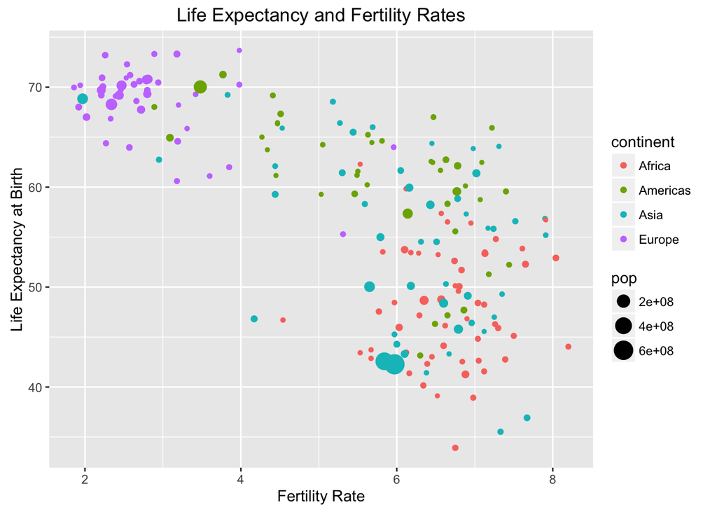

```r
p <- ggplot(filter(master, year == 1962, continent != "Oceania"), aes(x=fertility, y = life_exp))
p + geom_point(aes(size = pop, color=continent)) +
  ggtitle("Life Expectancy and Fertility Rates") +
  labs(x="Fertility Rate", y = "Life Expectancy at Birth")
```

Do you see a dichotomy? Explain.

## Problem 3.2

Now we will annotate the plot to show different types of countries.

Learn about OECD and OPEC. Add a couple of columns to your consolidated tables containing a logical vector that tells if a country is OECD and OPEC respectively. It is ok to base membership on 2015.

```r
# OECD Countries
oecd <- read.csv("OECD.csv")
#OPEC Countries
opec <- read.csv("OPEC.csv")
#Merge OPEC and OECD with Master
master <- left_join(master, oecd)
master <- left_join(master, opec)
```

### Problem 3.3

Make the same plot as in Problem 3.1, but this time use color to annotate the OECD countries and OPEC countries. For countries that are not part of these two organization annotate if they are from Africa, Asia, or the Americas.

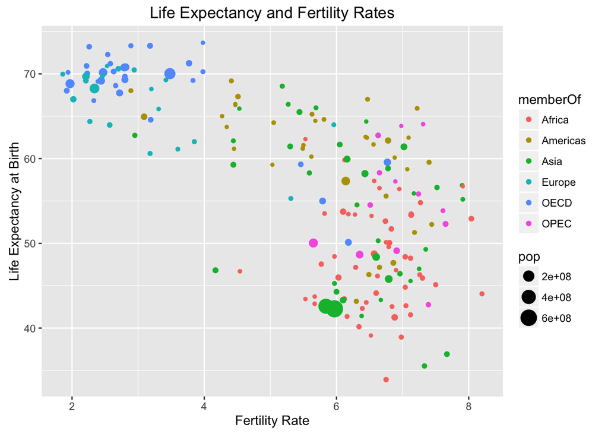

```r
# Consolidate groups or continents into a singe variable called "memberOf"
master$memberOf <- master$continent
master$memberOf[master$opec == "opec"] <- "OPEC"
master$memberOf[master$oecd == "oecd"] <- "OECD"
#Plot the data
p <- ggplot(filter(master, year == 1962, continent != "Oceania"), aes(x=fertility, y = life_exp))
p + geom_point(aes(size = pop, color=memberOf)) +
  ggtitle("Life Expectancy and Fertility Rates") +
  labs(x="Fertility Rate", y = "Life Expectancy at Birth")
```

How would you describe the dichotomy? When we graph the data explicitly identifying the OECD and OPEC countries, we can see that there is generally still a distinct dichotomy where the OECD countries are cluster in the top-left quadrant representing low fertility rates and high life expectancies, while OPEC countries see higher fertility rates, thought with perhaps slightly higher life expectancies than non-OPEC African countries. The dichotomy though is not as distinct as the purely continent-based dichotomy as there are a hand full of OECD countries intermingled with OPEC countries. Still, the two groups generally cluster together.

### Problem 3.4

Explore how this figure changes across time. Show us 4 figures that demonstrate how this figure changes through time.

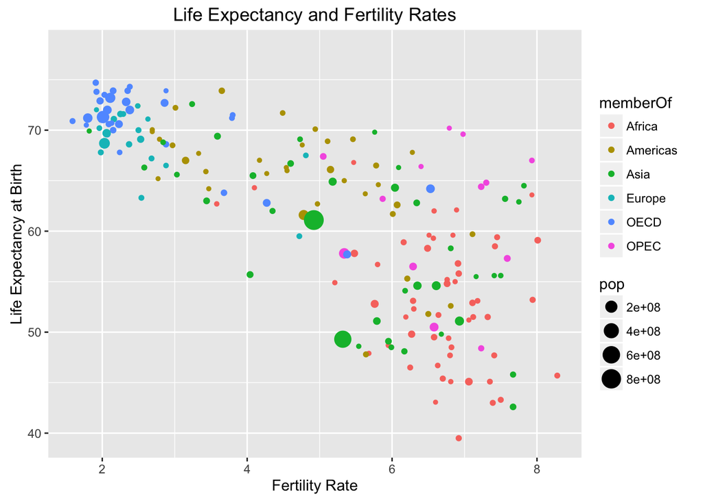

```r
# Life Expectancy and Fertility Rates 1972
p <- ggplot(filter(master, year == 1972, continent != "Oceania"), aes(x=fertility, y = life_exp))
p + geom_point(aes(size = pop, color=memberOf)) +
  ggtitle("Life Expectancy and Fertility Rates") +
  labs(x="Fertility Rate", y = "Life Expectancy at Birth")
```

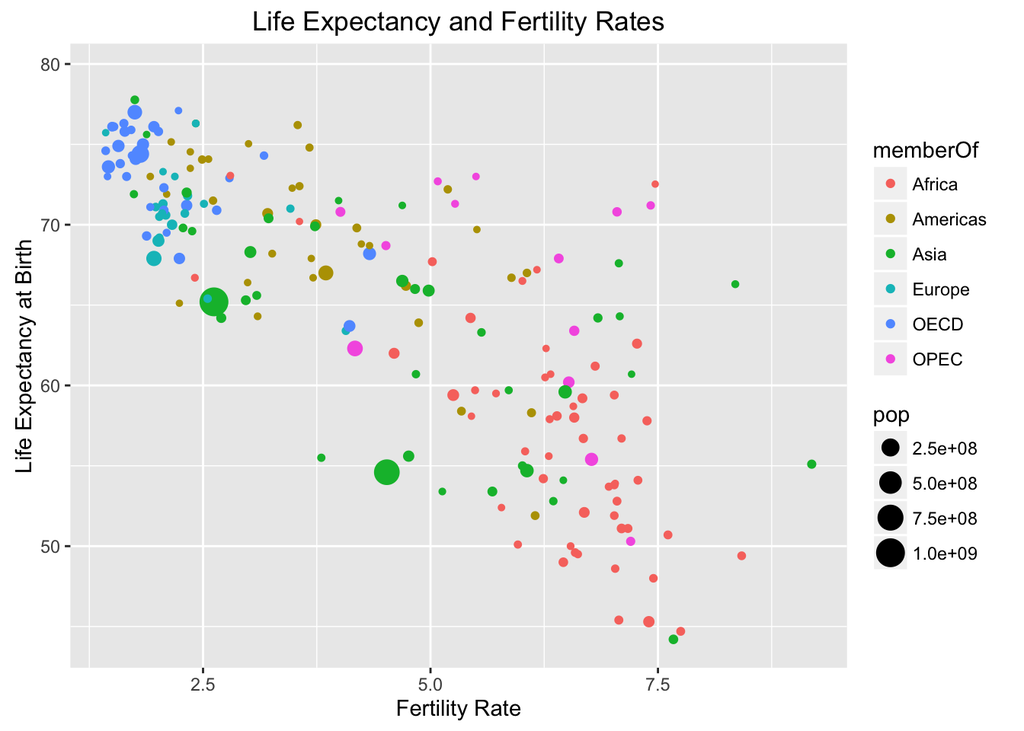

```r
# Life Expectancy and Fertility Rates 1982
p <- ggplot(filter(master, year == 1982, continent != "Oceania"), aes(x=fertility, y = life_exp))
p + geom_point(aes(size = pop, color=memberOf)) +
  ggtitle("Life Expectancy and Fertility Rates") +
  labs(x="Fertility Rate", y = "Life Expectancy at Birth")
```

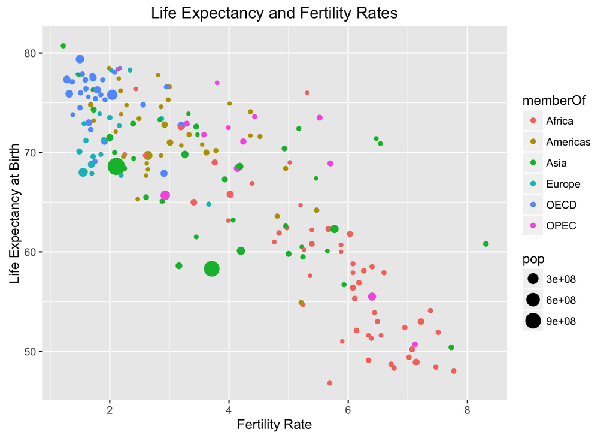

```r
# Life Expectancy and Fertility Rates 1992
p <- ggplot(filter(master, year == 1992, continent != "Oceania"), aes(x=fertility, y = life_exp))
p + geom_point(aes(size = pop, color=memberOf)) +
  ggtitle("Life Expectancy and Fertility Rates") +
  labs(x="Fertility Rate", y = "Life Expectancy at Birth")
```